# zomato

### Exploratory Data analysis by Python

#### Import Libraries

```python
import numpy as np
import pandas as pd
import matplotlib.pyplot as plt
import seaborn as sns
```

##### Presented By- Sukhada Andhare

```python
df = pd.read_csv("D:\Data analytica projects\pyhton project class\zomato.csv", encoding ='latin-1')
df.head(10)
```

|  | Restaurant ID | Restaurant Name | Country Code | City | Address | Locality | Locality Verbose | Longitude | Latitude | Cuisines | ... | Currency | Has Table booking | Has Online delivery | Is delivering now | Switch to order menu | Price range | Aggregate rating | Rating color | Rating text | Votes |
| --- | --- | --- | --- | --- | --- | --- | --- | --- | --- | --- | --- | --- | --- | --- | --- | --- | --- | --- | --- | --- | --- |
| 0 | 6317637 | Le Petit Souffle | 162 | Makati City | Third Floor, Century City Mall, Kalayaan Avenu... | Century City Mall, Poblacion, Makati City | Century City Mall, Poblacion, Makati City, Mak... | 121.027535 | 14.565443 | French, Japanese, Desserts | ... | Botswana Pula(P) | Yes | No | No | No | 3 | 4.8 | Dark Green | Excellent | 314 |
| 1 | 6304287 | Izakaya Kikufuji | 162 | Makati City | Little Tokyo, 2277 Chino Roces Avenue, Legaspi... | Little Tokyo, Legaspi Village, Makati City | Little Tokyo, Legaspi Village, Makati City, Ma... | 121.014101 | 14.553708 | Japanese | ... | Botswana Pula(P) | Yes | No | No | No | 3 | 4.5 | Dark Green | Excellent | 591 |
| 2 | 6300002 | Heat - Edsa Shangri-La | 162 | Mandaluyong City | Edsa Shangri-La, 1 Garden Way, Ortigas, Mandal... | Edsa Shangri-La, Ortigas, Mandaluyong City | Edsa Shangri-La, Ortigas, Mandaluyong City, Ma... | 121.056831 | 14.581404 | Seafood, Asian, Filipino, Indian | ... | Botswana Pula(P) | Yes | No | No | No | 4 | 4.4 | Green | Very Good | 270 |
| 3 | 6318506 | Ooma | 162 | Mandaluyong City | Third Floor, Mega Fashion Hall, SM Megamall, O... | SM Megamall, Ortigas, Mandaluyong City | SM Megamall, Ortigas, Mandaluyong City, Mandal... | 121.056475 | 14.585318 | Japanese, Sushi | ... | Botswana Pula(P) | No | No | No | No | 4 | 4.9 | Dark Green | Excellent | 365 |
| 4 | 6314302 | Sambo Kojin | 162 | Mandaluyong City | Third Floor, Mega Atrium, SM Megamall, Ortigas... | SM Megamall, Ortigas, Mandaluyong City | SM Megamall, Ortigas, Mandaluyong City, Mandal... | 121.057508 | 14.584450 | Japanese, Korean | ... | Botswana Pula(P) | Yes | No | No | No | 4 | 4.8 | Dark Green | Excellent | 229 |
| 5 | 18189371 | Din Tai Fung | 162 | Mandaluyong City | Ground Floor, Mega Fashion Hall, SM Megamall, ... | SM Megamall, Ortigas, Mandaluyong City | SM Megamall, Ortigas, Mandaluyong City, Mandal... | 121.056314 | 14.583764 | Chinese | ... | Botswana Pula(P) | No | No | No | No | 3 | 4.4 | Green | Very Good | 336 |
| 6 | 6300781 | Buffet 101 | 162 | Pasay City | Building K, SM By The Bay, Sunset Boulevard, M... | SM by the Bay, Mall of Asia Complex, Pasay City | SM by the Bay, Mall of Asia Complex, Pasay Cit... | 120.979667 | 14.531333 | Asian, European | ... | Botswana Pula(P) | Yes | No | No | No | 4 | 4.0 | Green | Very Good | 520 |
| 7 | 6301290 | Vikings | 162 | Pasay City | Building B, By The Bay, Seaside Boulevard, Mal... | SM by the Bay, Mall of Asia Complex, Pasay City | SM by the Bay, Mall of Asia Complex, Pasay Cit... | 120.979333 | 14.540000 | Seafood, Filipino, Asian, European | ... | Botswana Pula(P) | Yes | No | No | No | 4 | 4.2 | Green | Very Good | 677 |
| 8 | 6300010 | Spiral - Sofitel Philippine Plaza Manila | 162 | Pasay City | Plaza Level, Sofitel Philippine Plaza Manila, ... | Sofitel Philippine Plaza Manila, Pasay City | Sofitel Philippine Plaza Manila, Pasay City, P... | 120.980090 | 14.552990 | European, Asian, Indian | ... | Botswana Pula(P) | Yes | No | No | No | 4 | 4.9 | Dark Green | Excellent | 621 |
| 9 | 6314987 | Locavore | 162 | Pasig City | Brixton Technology Center, 10 Brixton Street, ... | Kapitolyo | Kapitolyo, Pasig City | 121.056532 | 14.572041 | Filipino | ... | Botswana Pula(P) | Yes | No | No | No | 3 | 4.8 | Dark Green | Excellent | 532 |

10 rows × 21 columns

# Improve our domain Knowledge about Zomato

### Lets Talks about Zomato and Familiar more about it:

- Zomato has Launched in 2010, its technology platform connects customers, restaurant partners and delivery partners, serving their multiple needs.
- Customers use its platform to search and discover restaurants, read and write customer generated reviews and view and upload photos, order food delivery, book a table and make payments while dining-out at restaurants.
- On the other hand, it provides restaurant partners with industry-specific marketing tools which enable them to engage and acquire customers to grow their business while also providing a reliable and efficient last mile delivery service. *Its team also operate a one-stop procurement solution, Hyperpure, which supplies high quality ingredients and kitchen products to restaurant partners. Zomato' team also provide our delivery partners with transparent and flexible earning opportunities.
- In the following code I use encoding = latin-1:

It maps all possible byte values to the first 256 Unicode code points, and thus ensures decoding errors will never occur regardless of the configured error handler</br>

- Use pandas documentation to find and explore whatever you like to search.. https://pandas.pydata.org/docs/

Zomato Restaurant contains the following variables (Columns):

• **Restaurant Id:** Unique id of every restaurant across various cities of the world  
• **Restaurant Name:** Name of the restaurant  
• **Country Code:** Country in which restaurant is located  
• **City:** City in which restaurant is located  
•**Address:** Address of the restaurant  
• **Locality:** Location in the city  
• **Locality Verbose:** Detailed description of the locality  
• **Longitude:** Longitude coordinate of the restaurant's location  
• **Latitude:** Latitude coordinate of the restaurant's location  
• **Cuisines:** Cuisines offered by the restaurant  
• **Average Cost for two:** Cost for two people in different currencies  
• **Currency:** Currency of the country  
• **Has Table booking:** yes/no  
• **Has Online delivery:** yes/ no  
• **Is delivering:** yes/ no  
• **Switch to order menu:** yes/no  
• **Price range:** range of price of food  
• **Aggregate Rating:** Average rating out of 5  
• **Rating color:** depending upon the average rating color  
• **Rating text:** text on the basis of rating of rating  
• **Votes:** Number of ratings casted by people

```python
# culumns in data
df.columns
```

```
Index(['Restaurant ID', 'Restaurant Name', 'Country Code', 'City', 'Address',
       'Locality', 'Locality Verbose', 'Longitude', 'Latitude', 'Cuisines',
       'Average Cost for two', 'Currency', 'Has Table booking',
       'Has Online delivery', 'Is delivering now', 'Switch to order menu',
       'Price range', 'Aggregate rating', 'Rating color', 'Rating text',
       'Votes'],
      dtype='object')
```

```python
# you can find data type by info
# Object: Categorical
df.info()
```

```
<class 'pandas.core.frame.DataFrame'>
RangeIndex: 9551 entries, 0 to 9550
Data columns (total 21 columns):
 #   Column                Non-Null Count  Dtype
---  ------                --------------  -----
 0   Restaurant ID         9551 non-null   int64
 1   Restaurant Name       9551 non-null   object
 2   Country Code          9551 non-null   int64
 3   City                  9551 non-null   object
 4   Address               9551 non-null   object
 5   Locality              9551 non-null   object
 6   Locality Verbose      9551 non-null   object
 7   Longitude             9551 non-null   float64
 8   Latitude              9551 non-null   float64
 9   Cuisines              9542 non-null   object
 10  Average Cost for two  9551 non-null   int64
 11  Currency              9551 non-null   object
 12  Has Table booking     9551 non-null   object
 13  Has Online delivery   9551 non-null   object
 14  Is delivering now     9551 non-null   object
 15  Switch to order menu  9551 non-null   object
 16  Price range           9551 non-null   int64
 17  Aggregate rating      9551 non-null   float64
 18  Rating color          9551 non-null   object
 19  Rating text           9551 non-null   object
 20  Votes                 9551 non-null   int64
dtypes: float64(3), int64(5), object(13)
memory usage: 1.5+ MB
```

```python
# Review descriptive data
df.describe()
```

|  | Restaurant ID | Country Code | Longitude | Latitude | Average Cost for two | Price range | Aggregate rating | Votes |
| --- | --- | --- | --- | --- | --- | --- | --- | --- |
| count | 9.551000e+03 | 9551.000000 | 9551.000000 | 9551.000000 | 9551.000000 | 9551.000000 | 9551.000000 | 9551.000000 |
| mean | 9.051128e+06 | 18.365616 | 64.126574 | 25.854381 | 1199.210763 | 1.804837 | 2.666370 | 156.909748 |
| std | 8.791521e+06 | 56.750546 | 41.467058 | 11.007935 | 16121.183073 | 0.905609 | 1.516378 | 430.169145 |
| min | 5.300000e+01 | 1.000000 | -157.948486 | -41.330428 | 0.000000 | 1.000000 | 0.000000 | 0.000000 |
| 25% | 3.019625e+05 | 1.000000 | 77.081343 | 28.478713 | 250.000000 | 1.000000 | 2.500000 | 5.000000 |
| 50% | 6.004089e+06 | 1.000000 | 77.191964 | 28.570469 | 400.000000 | 2.000000 | 3.200000 | 31.000000 |
| 75% | 1.835229e+07 | 1.000000 | 77.282006 | 28.642758 | 700.000000 | 2.000000 | 3.700000 | 131.000000 |
| max | 1.850065e+07 | 216.000000 | 174.832089 | 55.976980 | 800000.000000 | 4.000000 | 4.900000 | 10934.000000 |

Lets go to find out the number of observations and columns of Zomato Restaurant Dataset.

# In Data Analysis we do:

1. Missing Values
2. Explore about Numerical Valuables
3. Explore about Categorical valuables
4. Finding Relationship Between Features

```python
df.shape
```

```
(9551, 21)
```

```python
df.isnull().sum()
```

```
Restaurant ID           0
Restaurant Name         0
Country Code            0
City                    0
Address                 0
Locality                0
Locality Verbose        0
Longitude               0
Latitude                0
Cuisines                9
Average Cost for two    0
Currency                0
Has Table booking       0
Has Online delivery     0
Is delivering now       0
Switch to order menu    0
Price range             0
Aggregate rating        0
Rating color            0
Rating text             0
Votes                   0
dtype: int64
```

```python
[features for features in df.columns if df[features].isnull().sum()>0]
```

```
['Cuisines']
```

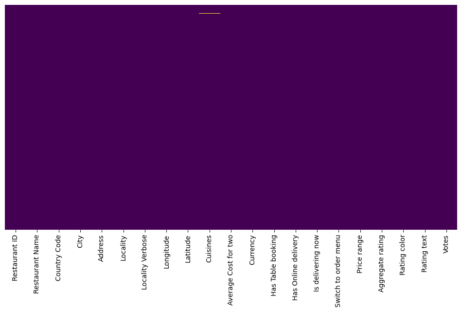

```python
import matplotlib
matplotlib.rcParams['figure.figsize']=(12,6)
sns.heatmap(df.isnull(), yticklabels =False, cbar=False, cmap= 'viridis')
```

```python
df_country = pd.read_csv("D:\Data analytica projects\pyhton project class\Pyhton project file.csv")
df_country.head()
```

|  | Country Code | Country |
| --- | --- | --- |
| 0 | 1 | India |
| 1 | 14 | Australia |
| 2 | 30 | Brazil |
| 3 | 37 | Canada |
| 4 | 94 | Indonesia |

```python
df.columns
```

```
Index(['Restaurant ID', 'Restaurant Name', 'Country Code', 'City', 'Address',
       'Locality', 'Locality Verbose', 'Longitude', 'Latitude', 'Cuisines',
       'Average Cost for two', 'Currency', 'Has Table booking',
       'Has Online delivery', 'Is delivering now', 'Switch to order menu',
       'Price range', 'Aggregate rating', 'Rating color', 'Rating text',
       'Votes'],
      dtype='object')
```

```python
df_country.columns
```

```
Index(['Country Code', 'Country'], dtype='object')
```

## At te moment I merge df, df_country where their country code are the same

```python
#At te moment I merge df, df_country where their country code are the same
Final_df=pd.merge(df, df_country, on= 'Country Code', how= 'left')
Final_df.head(2)
```

|  | Restaurant ID | Restaurant Name | Country Code | City | Address | Locality | Locality Verbose | Longitude | Latitude | Cuisines | ... | Has Table booking | Has Online delivery | Is delivering now | Switch to order menu | Price range | Aggregate rating | Rating color | Rating text | Votes | Country |
| --- | --- | --- | --- | --- | --- | --- | --- | --- | --- | --- | --- | --- | --- | --- | --- | --- | --- | --- | --- | --- | --- |
| 0 | 6317637 | Le Petit Souffle | 162 | Makati City | Third Floor, Century City Mall, Kalayaan Avenu... | Century City Mall, Poblacion, Makati City | Century City Mall, Poblacion, Makati City, Mak... | 121.027535 | 14.565443 | French, Japanese, Desserts | ... | Yes | No | No | No | 3 | 4.8 | Dark Green | Excellent | 314 | Phillipines |
| 1 | 6304287 | Izakaya Kikufuji | 162 | Makati City | Little Tokyo, 2277 Chino Roces Avenue, Legaspi... | Little Tokyo, Legaspi Village, Makati City | Little Tokyo, Legaspi Village, Makati City, Ma... | 121.014101 | 14.553708 | Japanese | ... | Yes | No | No | No | 3 | 4.5 | Dark Green | Excellent | 591 | Phillipines |

2 rows × 22 columns

```python
#At this step we want to know data types:
Final_df.dtypes
```

```
Restaurant ID             int64
Restaurant Name          object
Country Code              int64
City                     object
Address                  object
Locality                 object
Locality Verbose         object
Longitude               float64
Latitude                float64
Cuisines                 object
Average Cost for two      int64
Currency                 object
Has Table booking        object
Has Online delivery      object
Is delivering now        object
Switch to order menu     object
Price range               int64
Aggregate rating        float64
Rating color             object
Rating text              object
Votes                     int64
Country                  object
dtype: object
```

### At this step we want to know data types:

```python
print('Here, there is a list of Zomato country:')
for i in pd.unique(Final_df.Country): print(i)
print('Total number of countries is:', len(pd.unique(Final_df.Country)))
```

```
Here, there is a list of Zomato country:
Phillipines
Brazil
United States
Australia
Canada
Singapore
UAE
India
Indonesia
New Zealand
United Kingdom
Qatar
South Africa
Sri Lanka
Turkey
Total number of countries is: 15
```

### Lets go to Explorer Dataset, Lets pick up something

##### How many countries are there?

```python
#Lets go to Explorer Dataset, Lets pick up something
#How many countries are there?
Final_df.columns
```

```
Index(['Restaurant ID', 'Restaurant Name', 'Country Code', 'City', 'Address',
       'Locality', 'Locality Verbose', 'Longitude', 'Latitude', 'Cuisines',
       'Average Cost for two', 'Currency', 'Has Table booking',
       'Has Online delivery', 'Is delivering now', 'Switch to order menu',
       'Price range', 'Aggregate rating', 'Rating color', 'Rating text',
       'Votes', 'Country'],
      dtype='object')
```

```python
Final_df.Country.value_counts()
```

```
India             8652
United States      434
United Kingdom      80
Brazil              60
UAE                 60
South Africa        60
New Zealand         40
Turkey              34
Australia           24
Phillipines         22
Indonesia           21
Singapore           20
Qatar               20
Sri Lanka           20
Canada               4
Name: Country, dtype: int64
```

### Maximum Transaction happen in India by 8652

```python
#Maximum Transaction happen in India by 8652
Final_df.Country.value_counts().index
```

```
Index(['India', 'United States', 'United Kingdom', 'Brazil', 'UAE',
       'South Africa', 'New Zealand', 'Turkey', 'Australia', 'Phillipines',
       'Indonesia', 'Singapore', 'Qatar', 'Sri Lanka', 'Canada'],
      dtype='object')
```

```python
country_name = Final_df.Country.value_counts().index
country_name
```

```
Index(['India', 'United States', 'United Kingdom', 'Brazil', 'UAE',
       'South Africa', 'New Zealand', 'Turkey', 'Australia', 'Phillipines',
       'Indonesia', 'Singapore', 'Qatar', 'Sri Lanka', 'Canada'],
      dtype='object')
```

```python
country_val = Final_df.Country.value_counts().values
country_val
```

```
array([8652,  434,   80,   60,   60,   60,   40,   34,   24,   22,   21,
         20,   20,   20,    4], dtype=int64)
```

## Lets do some Plots

#### 1- Top 3 Countries that uses Zomato

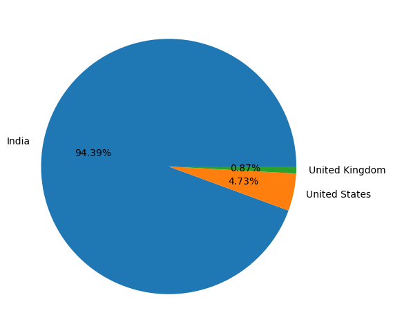

```python
#Lets do some Plots
#1- Top 3 Countries that uses Zomato
plt.pie(country_val[:3], labels=country_name[:3],autopct ='%1.2f%%');
```

##### Observation:Zomato Maximum Records are from India After that USA and then United Kingdom

##### How many Variable Are there?

```python
'''Observation:Zomato Maximum Records are from India After that USA and then United Kingdom
How many Variable Are there?'''
Final_df.columns
```

```
Index(['Restaurant ID', 'Restaurant Name', 'Country Code', 'City', 'Address',
       'Locality', 'Locality Verbose', 'Longitude', 'Latitude', 'Cuisines',
       'Average Cost for two', 'Currency', 'Has Table booking',
       'Has Online delivery', 'Is delivering now', 'Switch to order menu',
       'Price range', 'Aggregate rating', 'Rating color', 'Rating text',
       'Votes', 'Country'],
      dtype='object')
```

```python
Final_df.groupby(['Aggregate rating','Rating color','Rating text']).size()
```

```
Aggregate rating  Rating color  Rating text
0.0               White         Not rated      2148
1.8               Red           Poor              1
1.9               Red           Poor              2
2.0               Red           Poor              7
2.1               Red           Poor             15
2.2               Red           Poor             27
2.3               Red           Poor             47
2.4               Red           Poor             87
2.5               Orange        Average         110
2.6               Orange        Average         191
2.7               Orange        Average         250
2.8               Orange        Average         315
2.9               Orange        Average         381
3.0               Orange        Average         468
3.1               Orange        Average         519
3.2               Orange        Average         522
3.3               Orange        Average         483
3.4               Orange        Average         498
3.5               Yellow        Good            480
3.6               Yellow        Good            458
3.7               Yellow        Good            427
3.8               Yellow        Good            400
3.9               Yellow        Good            335
4.0               Green         Very Good       266
4.1               Green         Very Good       274
4.2               Green         Very Good       221
4.3               Green         Very Good       174
4.4               Green         Very Good       144
4.5               Dark Green    Excellent        95
4.6               Dark Green    Excellent        78
4.7               Dark Green    Excellent        42
4.8               Dark Green    Excellent        25
4.9               Dark Green    Excellent        61
dtype: int64
```

```python
Final_df.groupby(['Aggregate rating','Rating color','Rating text']).size().reset_index()
```

|  | Aggregate rating | Rating color | Rating text | 0 |
| --- | --- | --- | --- | --- |
| 0 | 0.0 | White | Not rated | 2148 |
| 1 | 1.8 | Red | Poor | 1 |
| 2 | 1.9 | Red | Poor | 2 |
| 3 | 2.0 | Red | Poor | 7 |
| 4 | 2.1 | Red | Poor | 15 |
| 5 | 2.2 | Red | Poor | 27 |
| 6 | 2.3 | Red | Poor | 47 |
| 7 | 2.4 | Red | Poor | 87 |
| 8 | 2.5 | Orange | Average | 110 |
| 9 | 2.6 | Orange | Average | 191 |
| 10 | 2.7 | Orange | Average | 250 |
| 11 | 2.8 | Orange | Average | 315 |
| 12 | 2.9 | Orange | Average | 381 |
| 13 | 3.0 | Orange | Average | 468 |
| 14 | 3.1 | Orange | Average | 519 |
| 15 | 3.2 | Orange | Average | 522 |
| 16 | 3.3 | Orange | Average | 483 |
| 17 | 3.4 | Orange | Average | 498 |
| 18 | 3.5 | Yellow | Good | 480 |
| 19 | 3.6 | Yellow | Good | 458 |
| 20 | 3.7 | Yellow | Good | 427 |
| 21 | 3.8 | Yellow | Good | 400 |
| 22 | 3.9 | Yellow | Good | 335 |
| 23 | 4.0 | Green | Very Good | 266 |
| 24 | 4.1 | Green | Very Good | 274 |
| 25 | 4.2 | Green | Very Good | 221 |
| 26 | 4.3 | Green | Very Good | 174 |
| 27 | 4.4 | Green | Very Good | 144 |
| 28 | 4.5 | Dark Green | Excellent | 95 |
| 29 | 4.6 | Dark Green | Excellent | 78 |
| 30 | 4.7 | Dark Green | Excellent | 42 |
| 31 | 4.8 | Dark Green | Excellent | 25 |
| 32 | 4.9 | Dark Green | Excellent | 61 |

```python
rating = Final_df.groupby(['Aggregate rating','Rating color','Rating text']).size().reset_index().rename(columns={0:'Rating Count'})
rating
```

|  | Aggregate rating | Rating color | Rating text | Rating Count |
| --- | --- | --- | --- | --- |
| 0 | 0.0 | White | Not rated | 2148 |
| 1 | 1.8 | Red | Poor | 1 |
| 2 | 1.9 | Red | Poor | 2 |
| 3 | 2.0 | Red | Poor | 7 |
| 4 | 2.1 | Red | Poor | 15 |
| 5 | 2.2 | Red | Poor | 27 |
| 6 | 2.3 | Red | Poor | 47 |
| 7 | 2.4 | Red | Poor | 87 |
| 8 | 2.5 | Orange | Average | 110 |
| 9 | 2.6 | Orange | Average | 191 |
| 10 | 2.7 | Orange | Average | 250 |
| 11 | 2.8 | Orange | Average | 315 |
| 12 | 2.9 | Orange | Average | 381 |
| 13 | 3.0 | Orange | Average | 468 |
| 14 | 3.1 | Orange | Average | 519 |
| 15 | 3.2 | Orange | Average | 522 |
| 16 | 3.3 | Orange | Average | 483 |
| 17 | 3.4 | Orange | Average | 498 |
| 18 | 3.5 | Yellow | Good | 480 |
| 19 | 3.6 | Yellow | Good | 458 |
| 20 | 3.7 | Yellow | Good | 427 |
| 21 | 3.8 | Yellow | Good | 400 |
| 22 | 3.9 | Yellow | Good | 335 |
| 23 | 4.0 | Green | Very Good | 266 |
| 24 | 4.1 | Green | Very Good | 274 |
| 25 | 4.2 | Green | Very Good | 221 |
| 26 | 4.3 | Green | Very Good | 174 |
| 27 | 4.4 | Green | Very Good | 144 |
| 28 | 4.5 | Dark Green | Excellent | 95 |
| 29 | 4.6 | Dark Green | Excellent | 78 |
| 30 | 4.7 | Dark Green | Excellent | 42 |
| 31 | 4.8 | Dark Green | Excellent | 25 |
| 32 | 4.9 | Dark Green | Excellent | 61 |

#### Observation:

```python
rating.head()
```

|  | Aggregate rating | Rating color | Rating text | Rating Count |
| --- | --- | --- | --- | --- |
| 0 | 0.0 | White | Not rated | 2148 |
| 1 | 1.8 | Red | Poor | 1 |
| 2 | 1.9 | Red | Poor | 2 |
| 3 | 2.0 | Red | Poor | 7 |
| 4 | 2.1 | Red | Poor | 15 |

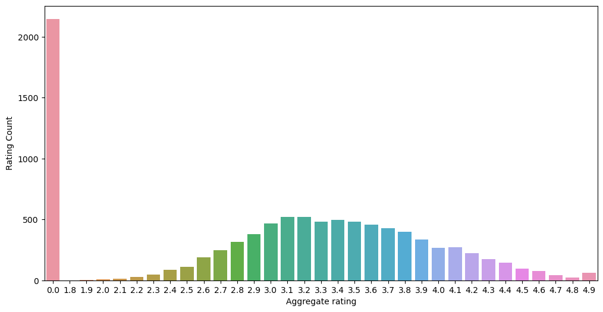

```python
import matplotlib
matplotlib.rcParams['figure.figsize']=(12,6)
sns.barplot(x= 'Aggregate rating', y='Rating Count', data= rating);
```

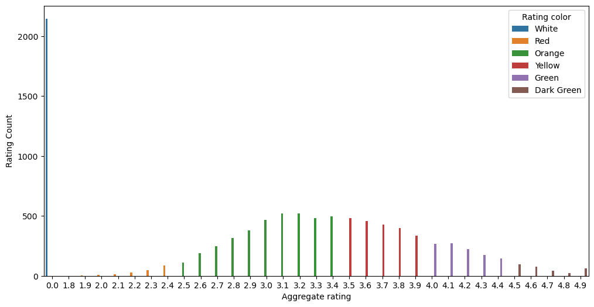

```python
sns.barplot(x= 'Aggregate rating', y='Rating Count', data= rating, hue='Rating color');
```

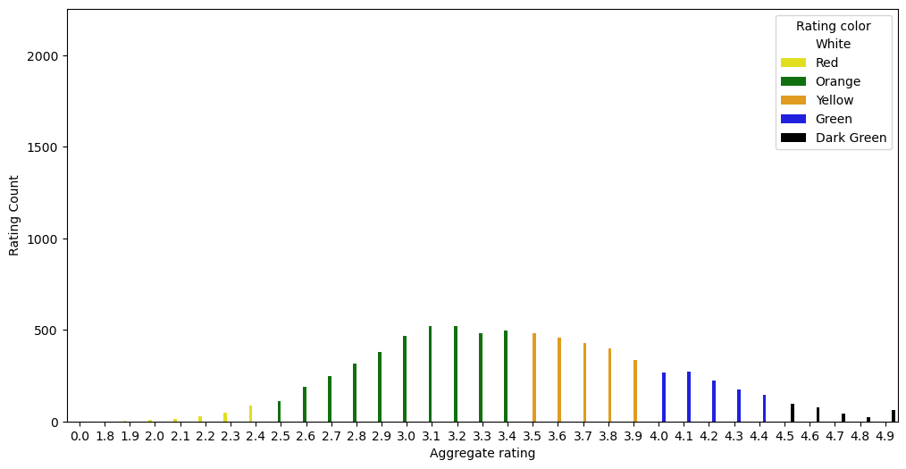

```python
sns.barplot(x= 'Aggregate rating', y='Rating Count', data= rating,hue='Rating color', palette=['white', 'yellow', 'green', 'orange','blue','black']);
```

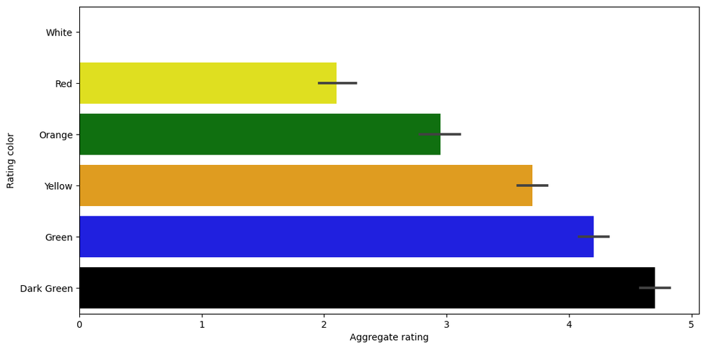

```python
sns.barplot(x= 'Aggregate rating', y='Rating color', data= rating, palette=['white', 'yellow', 'green', 'orange','blue','black']);
```

### Observation:

1- Not Rated count is very high  
2- Maximum Number of rating are between 2.5 to 3.6

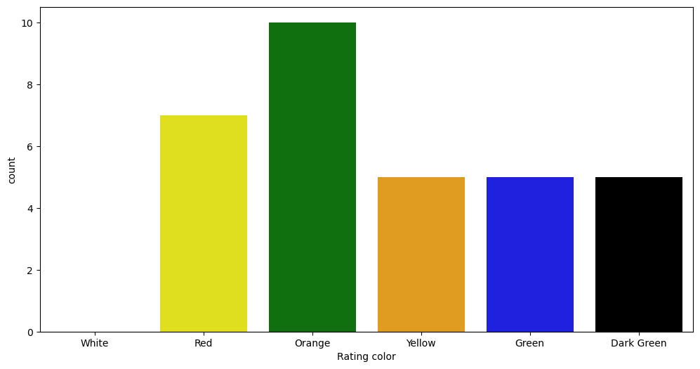

```python
## Countplot
sns.countplot(x='Rating color', data= rating, palette= ['white', 'yellow', 'green', 'orange','blue','black'])
```

```python
rating
```

|  | Aggregate rating | Rating color | Rating text | Rating Count |
| --- | --- | --- | --- | --- |
| 0 | 0.0 | White | Not rated | 2148 |
| 1 | 1.8 | Red | Poor | 1 |
| 2 | 1.9 | Red | Poor | 2 |
| 3 | 2.0 | Red | Poor | 7 |
| 4 | 2.1 | Red | Poor | 15 |
| 5 | 2.2 | Red | Poor | 27 |
| 6 | 2.3 | Red | Poor | 47 |
| 7 | 2.4 | Red | Poor | 87 |
| 8 | 2.5 | Orange | Average | 110 |
| 9 | 2.6 | Orange | Average | 191 |
| 10 | 2.7 | Orange | Average | 250 |
| 11 | 2.8 | Orange | Average | 315 |
| 12 | 2.9 | Orange | Average | 381 |
| 13 | 3.0 | Orange | Average | 468 |
| 14 | 3.1 | Orange | Average | 519 |
| 15 | 3.2 | Orange | Average | 522 |
| 16 | 3.3 | Orange | Average | 483 |
| 17 | 3.4 | Orange | Average | 498 |
| 18 | 3.5 | Yellow | Good | 480 |
| 19 | 3.6 | Yellow | Good | 458 |
| 20 | 3.7 | Yellow | Good | 427 |
| 21 | 3.8 | Yellow | Good | 400 |
| 22 | 3.9 | Yellow | Good | 335 |
| 23 | 4.0 | Green | Very Good | 266 |
| 24 | 4.1 | Green | Very Good | 274 |
| 25 | 4.2 | Green | Very Good | 221 |
| 26 | 4.3 | Green | Very Good | 174 |
| 27 | 4.4 | Green | Very Good | 144 |
| 28 | 4.5 | Dark Green | Excellent | 95 |
| 29 | 4.6 | Dark Green | Excellent | 78 |
| 30 | 4.7 | Dark Green | Excellent | 42 |
| 31 | 4.8 | Dark Green | Excellent | 25 |
| 32 | 4.9 | Dark Green | Excellent | 61 |

# Find country names that have given zero rating

```python
Final_df.columns
```

```
Index(['Restaurant ID', 'Restaurant Name', 'Country Code', 'City', 'Address',
       'Locality', 'Locality Verbose', 'Longitude', 'Latitude', 'Cuisines',
       'Average Cost for two', 'Currency', 'Has Table booking',
       'Has Online delivery', 'Is delivering now', 'Switch to order menu',
       'Price range', 'Aggregate rating', 'Rating color', 'Rating text',
       'Votes', 'Country'],
      dtype='object')
```

```python
Final_df[Final_df['Rating color']== 'White']
```

|  | Restaurant ID | Restaurant Name | Country Code | City | Address | Locality | Locality Verbose | Longitude | Latitude | Cuisines | ... | Has Table booking | Has Online delivery | Is delivering now | Switch to order menu | Price range | Aggregate rating | Rating color | Rating text | Votes | Country |
| --- | --- | --- | --- | --- | --- | --- | --- | --- | --- | --- | --- | --- | --- | --- | --- | --- | --- | --- | --- | --- | --- |
| 30 | 6600060 | Sandubas Cafí© | 30 | Brasí_lia | Edifí_cio Josí© Severo, SCS 6, Bloco A, Loja 9... | Asa Sul | Asa Sul, Brasí_lia | -47.890167 | -15.797000 | Brazilian, Cafe | ... | No | No | No | No | 1 | 0.0 | White | Not rated | 2 | Brazil |
| 58 | 7305048 | Quiosque Chopp Brahma | 30 | Rio de Janeiro | Madureira Shopping - Loja 289/290, Piso 2, Est... | Madureira | Madureira, Rio de Janeiro | -43.341164 | -22.870413 | Bar Food, Brazilian | ... | No | No | No | No | 3 | 0.0 | White | Not rated | 1 | Brazil |
| 69 | 6710645 | Cantinho da Gula | 30 | Sí£o Paulo | Rua Pedroso Alvarenga, 522, Itaim Bibi, Sí£o P... | Itaim Bibi | Itaim Bibi, Sí£o Paulo | -46.675667 | -23.581000 | Brazilian | ... | No | No | No | No | 2 | 0.0 | White | Not rated | 0 | Brazil |
| 77 | 6701419 | Divino Fogí£o | 30 | Sí£o Paulo | Shopping MetríÇ Santa Cruz - Piso L2, Rua Domi... | Shopping MetríÇ Santa Cruz, Vila Mariana | Shopping MetríÇ Santa Cruz, Vila Mariana, Sí£o... | -46.637167 | -23.599500 | Brazilian, Mineira | ... | No | No | No | No | 3 | 0.0 | White | Not rated | 2 | Brazil |
| 78 | 6703956 | Super Grill | 30 | Sí£o Paulo | Shopping Morumbi - Piso Lazer, Avenida Roque P... | Shopping Morumbi, Santo Amaro | Shopping Morumbi, Santo Amaro, Sí£o Paulo | -46.698574 | -23.622925 | Brazilian | ... | No | No | No | No | 2 | 0.0 | White | Not rated | 2 | Brazil |
| ... | ... | ... | ... | ... | ... | ... | ... | ... | ... | ... | ... | ... | ... | ... | ... | ... | ... | ... | ... | ... | ... |
| 9109 | 18277023 | Bread & Pasta | 1 | Noida | Shop 15, Near HDFC Bank, Tulip Mall, Sector 48... | Tulip Mall, Sector 48, Noida | Tulip Mall, Sector 48, Noida, Noida | 77.367303 | 28.557929 | Fast Food | ... | No | No | No | No | 1 | 0.0 | White | Not rated | 1 | India |
| 9110 | 18313203 | Chillies Cafe | 1 | Noida | G-11, Tulip Mall, Sector 48, Noida | Tulip Mall, Sector 48, Noida | Tulip Mall, Sector 48, Noida, Noida | 77.367188 | 28.557842 | Fast Food | ... | No | No | No | No | 2 | 0.0 | White | Not rated | 3 | India |
| 9111 | 18254559 | Platters | 1 | Noida | Shop 1, Tulip Mall, Near HDFC Bank, Sector 48,... | Tulip Mall, Sector 48, Noida | Tulip Mall, Sector 48, Noida, Noida | 77.367322 | 28.557930 | North Indian, Chinese | ... | No | No | No | No | 2 | 0.0 | White | Not rated | 0 | India |
| 9112 | 18255132 | The Grand | 1 | Noida | G-5, Tulip Mall, Sector 48, Noida | Tulip Mall, Sector 48, Noida | Tulip Mall, Sector 48, Noida, Noida | 77.367188 | 28.557852 | Raw Meats, Fast Food | ... | No | No | No | No | 1 | 0.0 | White | Not rated | 1 | India |
| 9351 | 18273002 | Damascena Coffee House | 215 | Birmingham | 133 Alcester Road, Moseley, Birmingham | Moseley | Moseley, Birmingham | -1.888555 | 52.446302 | Greek, Mediterranean, Middle Eastern | ... | No | No | No | No | 2 | 0.0 | White | Not rated | 3 | United Kingdom |

2148 rows × 22 columns

```python
Final_df[Final_df['Rating color']== 'White'].groupby(['Aggregate rating','Country']).size().reset_index()
```

|  | Aggregate rating | Country | 0 |
| --- | --- | --- | --- |
| 0 | 0.0 | Brazil | 5 |
| 1 | 0.0 | India | 2139 |
| 2 | 0.0 | United Kingdom | 1 |
| 3 | 0.0 | United States | 3 |

## Observation:¶

### Maximum number of 0 ratings are from India customers

```python
## find out which currency is used by which country
Final_df.columns
```

```
Index(['Restaurant ID', 'Restaurant Name', 'Country Code', 'City', 'Address',
       'Locality', 'Locality Verbose', 'Longitude', 'Latitude', 'Cuisines',
       'Average Cost for two', 'Currency', 'Has Table booking',
       'Has Online delivery', 'Is delivering now', 'Switch to order menu',
       'Price range', 'Aggregate rating', 'Rating color', 'Rating text',
       'Votes', 'Country'],
      dtype='object')
```

### find out which currency is used by which country

```python
Final_df[['Country','Currency']].groupby(['Country','Currency']).size().reset_index()
```

|  | Country | Currency | 0 |
| --- | --- | --- | --- |
| 0 | Australia | Dollar($) | 24 |
| 1 | Brazil | Brazilian Real(R$) | 60 |
| 2 | Canada | Dollar($) | 4 |
| 3 | India | Indian Rupees(Rs.) | 8652 |
| 4 | Indonesia | Indonesian Rupiah(IDR) | 21 |
| 5 | New Zealand | NewZealand($) | 40 |
| 6 | Phillipines | Botswana Pula(P) | 22 |
| 7 | Qatar | Qatari Rial(QR) | 20 |
| 8 | Singapore | Dollar($) | 20 |
| 9 | South Africa | Rand(R) | 60 |
| 10 | Sri Lanka | Sri Lankan Rupee(LKR) | 20 |
| 11 | Turkey | Turkish Lira(TL) | 34 |
| 12 | UAE | Emirati Diram(AED) | 60 |
| 13 | United Kingdom | Pounds(£) | 80 |
| 14 | United States | Dollar($) | 434 |

### Which countries do have online deliveries

```python
Final_df[Final_df['Has Online delivery']=='Yes'].Country.value_counts()
```

```
India    2423
UAE        28
Name: Country, dtype: int64
```

```python
Final_df[['Has Online delivery', 'Country']].groupby(['Has Online delivery','Country']).size().reset_index()
```

|  | Has Online delivery | Country | 0 |
| --- | --- | --- | --- |
| 0 | No | Australia | 24 |
| 1 | No | Brazil | 60 |
| 2 | No | Canada | 4 |
| 3 | No | India | 6229 |
| 4 | No | Indonesia | 21 |
| 5 | No | New Zealand | 40 |
| 6 | No | Phillipines | 22 |
| 7 | No | Qatar | 20 |
| 8 | No | Singapore | 20 |
| 9 | No | South Africa | 60 |
| 10 | No | Sri Lanka | 20 |
| 11 | No | Turkey | 34 |
| 12 | No | UAE | 32 |
| 13 | No | United Kingdom | 80 |
| 14 | No | United States | 434 |
| 15 | Yes | India | 2423 |
| 16 | Yes | UAE | 28 |

# Observation¶

### Online deliveries are available in India and UAE

#### Create a pie chart for cities distribution

```python
city_values=Final_df.City.value_counts().values
city_labels=Final_df.City.value_counts().values
```

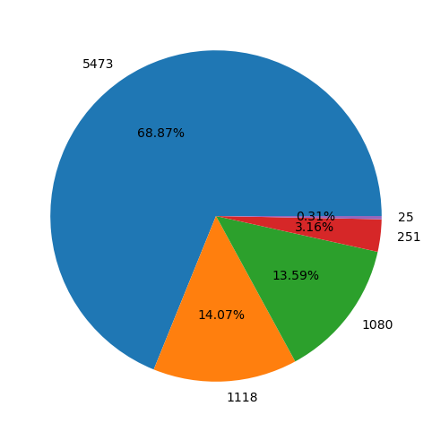

```python
plt.pie(city_values[:5],labels=city_labels[:5], autopct='%1.2f%%');
```